# Opgaver_3_mandag

2024-09-16

Opgave HS.13: Sudoko Opgave HS.14: Højde- og vægtdata Opgave 5.8: Opløsningsmidler Opgave 5.10: Priser på landbrugsejendomme. I spørgsmål 3 behøver du ikke beregne KI. Opgave HS.15: Gæt på punktplot

# HS.13

## Opgave 1

```r
# install.packages("readxl")

library(readxl)
library("ggplot2")
library(tidyverse)
sudokuData <- read_excel("data/sudoku-sd1.xlsx")

# Feature engineering
sudokuData <- transform(sudokuData, tid = 60 * min + sek)
sudokuData <- na.omit(sudokuData)

head(sudokuData , 3)
```

```
##     type korrekt min sek  erfaring studieretning tid
## 1    Tal      Ja   2   8  Over5aar   JordbrugsOk 128
## 2 Graesk      Ja   1  23 Under5aar   JordbrugsOk  83
## 3 Graesk      Ja   2  45 Under5aar   JordbrugsOk 165
```

## Opgave 2

Resposvariabel : tid

Forklarende variabel : type

Da vi har en kontinuert responsvariabel og en kategorisk forklarende variabel vælges den ensides ANOVA

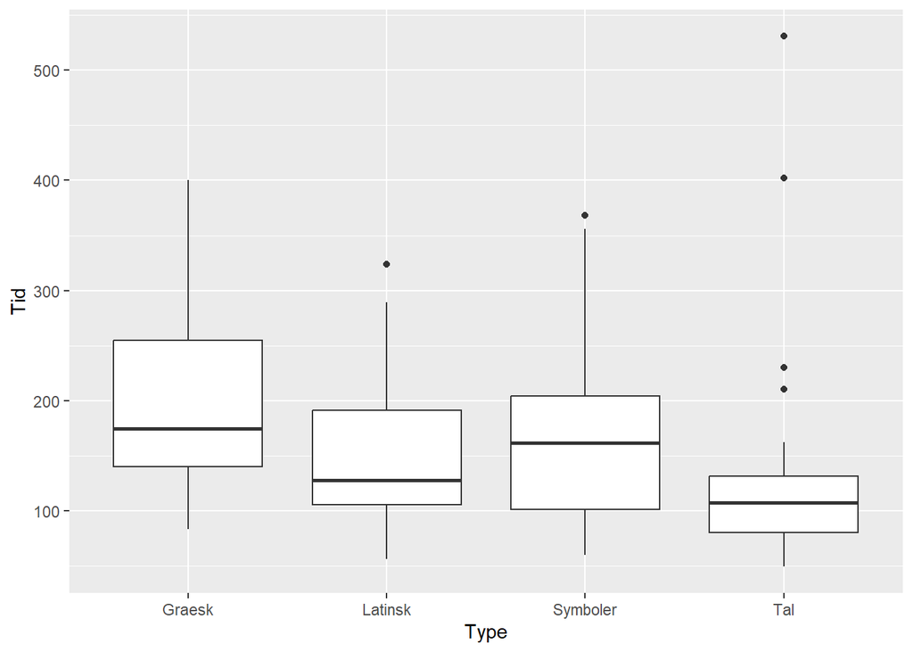

```r
ggplot(data = sudokuData, aes(x = type, y = tid)) +
  geom_boxplot(outliers = TRUE) +
  xlab("Type") + ylab("Tid")
```

## opgave 3

```r
summarize(group_by(sudokuData, type), n = n(),
          tid_mean = mean(tid), tid_sd = sd(tid))
```

```
## # A tibble: 4 × 4
##   type         n tid_mean tid_sd
##   <chr>    <int>    <dbl>  <dbl>
## 1 Graesk      24     207.   95.3
## 2 Latinsk     28     149.   67.1
## 3 Symboler    30     167.   85.3
## 4 Tal         29     135.  102.
```

```r
# Perfome anova
linreg <- lm(tid ~ type-1, data = sudokuData)
summary(linreg, n = length())
```

```
##
## Call:
## lm(formula = tid ~ type - 1, data = sudokuData)
##
## Residuals:
##     Min      1Q  Median      3Q     Max
## -123.65  -58.26  -22.76   30.61  396.24
##
## Coefficients:
##              Estimate Std. Error t value Pr(>|t|)
## typeGraesk     206.65      18.03  11.460  < 2e-16 ***
## typeLatinsk    148.68      16.69   8.906 1.51e-14 ***
## typeSymboler   167.13      16.13  10.363  < 2e-16 ***
## typeTal        134.76      16.40   8.215 5.30e-13 ***
## ---
## Signif. codes:  0 '***' 0.001 '**' 0.01 '*' 0.05 '.' 0.1 ' ' 1
##
## Residual standard error: 88.34 on 107 degrees of freedom
## Multiple R-squared:  0.7828, Adjusted R-squared:  0.7746
## F-statistic: 96.38 on 4 and 107 DF,  p-value: < 2.2e-16
```

Standard error for græsk er størst fordi der er færrest observationer. Rækkefølgen passer 1-1 med antal af observationer.

## opgave 4

```r
head(sudokuData, n = 3)
```

```
##     type korrekt min sek  erfaring studieretning tid
## 1    Tal      Ja   2   8  Over5aar   JordbrugsOk 128
## 2 Graesk      Ja   1  23 Under5aar   JordbrugsOk  83
## 3 Graesk      Ja   2  45 Under5aar   JordbrugsOk 165
```

```r
sudokuData <- data.frame(sudokuData)
sudokuData$myType <- relevel(factor(sudokuData$type), ref="Latinsk")


model3 <- lm(tid ~ myType, data=sudokuData)
summary(model3)
```

```
##
## Call:
## lm(formula = tid ~ myType, data = sudokuData)
##
## Residuals:
##     Min      1Q  Median      3Q     Max
## -123.65  -58.26  -22.76   30.61  396.24
##
## Coefficients:
##                Estimate Std. Error t value Pr(>|t|)
## (Intercept)      148.68      16.69   8.906 1.51e-14 ***
## myTypeGraesk      57.97      24.57   2.359   0.0201 *
## myTypeSymboler    18.45      23.21   0.795   0.4284
## myTypeTal        -13.92      23.40  -0.595   0.5533
## ---
## Signif. codes:  0 '***' 0.001 '**' 0.01 '*' 0.05 '.' 0.1 ' ' 1
##
## Residual standard error: 88.34 on 107 degrees of freedom
## Multiple R-squared:  0.08251,    Adjusted R-squared:  0.05678
## F-statistic: 3.207 on 3 and 107 DF,  p-value: 0.02607
```

## Opgave 5

```r
confint(model3)
```

```
##                     2.5 %    97.5 %
## (Intercept)    115.584011 181.77313
## myTypeGraesk     9.254638 106.68239
## myTypeSymboler -27.561357  64.47088
## myTypeTal      -60.317501  32.47760
```

Vi er sikker på at forskellen i tid mellem latinsk og græsk er mellem 9 og 106 sekunder. Vi kan konlkludere at der er en forskel mellem tiden i de to typer, da 0 ikke ligger i intervallet.

## Opgave 6

```r
sudokuData <- data.frame(sudokuData)
sudokuData$talType <- relevel(factor(sudokuData$type), ref="Tal")


model4 <- lm(tid ~ myType, data=sudokuData)
summary(model4)
```

```
##
## Call:
## lm(formula = tid ~ myType, data = sudokuData)
##
## Residuals:
##     Min      1Q  Median      3Q     Max
## -123.65  -58.26  -22.76   30.61  396.24
##
## Coefficients:
##                Estimate Std. Error t value Pr(>|t|)
## (Intercept)      148.68      16.69   8.906 1.51e-14 ***
## myTypeGraesk      57.97      24.57   2.359   0.0201 *
## myTypeSymboler    18.45      23.21   0.795   0.4284
## myTypeTal        -13.92      23.40  -0.595   0.5533
## ---
## Signif. codes:  0 '***' 0.001 '**' 0.01 '*' 0.05 '.' 0.1 ' ' 1
##
## Residual standard error: 88.34 on 107 degrees of freedom
## Multiple R-squared:  0.08251,    Adjusted R-squared:  0.05678
## F-statistic: 3.207 on 3 and 107 DF,  p-value: 0.02607
```

```r
confint(model4)
```

```
##                     2.5 %    97.5 %
## (Intercept)    115.584011 181.77313
## myTypeGraesk     9.254638 106.68239
## myTypeSymboler -27.561357  64.47088
## myTypeTal      -60.317501  32.47760
```

I de intervaller som ikke indenholder 0, kan vi med 95% sikkerhed sige at der er en forskel, som ikke skyldes tilfældighed.

# HS. 14

## Opgave 1

Vi har to kvantitative data + kontinuert responsvariabel, da anvendes linear regression.

```r
data_horse <- read_excel(path = "data/stud2017-v2.xls")

head(data_horse, 3)
```

```
## # A tibble: 3 × 12
##      id studie  alder kon   hojde vaegt helleVaegt hest  matematik figur1 figur2
##   <dbl> <chr>   <dbl> <chr> <dbl> <dbl>      <dbl> <chr>     <dbl>  <dbl>  <dbl>
## 1     4 Naturr…    22 Mand    178    68         64 Nej           7     NA     NA
## 2     5 Husdyr…    21 Kvin…   175    71         65 Nej          12     NA     NA
## 3     6 Jordbr…    22 Mand    176    90         60 Ja            4     NA     NA
## # ℹ 1 more variable: figur3 <dbl>
```

```r
data_horse <- data.frame(data_horse)
linreg <- lm(vaegt ~ hojde, data = data_horse) # Fit
summary(linreg)
```

```
##
## Call:
## lm(formula = vaegt ~ hojde, data = data_horse)
##
## Residuals:
##     Min      1Q  Median      3Q     Max
## -17.828  -6.056  -1.536   4.132  31.740
##
## Coefficients:
##              Estimate Std. Error t value Pr(>|t|)
## (Intercept) -86.76014   14.42672  -6.014 1.32e-08 ***
## hojde         0.89771    0.08318  10.792  < 2e-16 ***
## ---
## Signif. codes:  0 '***' 0.001 '**' 0.01 '*' 0.05 '.' 0.1 ' ' 1
##
## Residual standard error: 9.297 on 150 degrees of freedom
##   (5 observations deleted due to missingness)
## Multiple R-squared:  0.4371, Adjusted R-squared:  0.4333
## F-statistic: 116.5 on 1 and 150 DF,  p-value: < 2.2e-16
```

```r
confint(linreg)
```

```
##                    2.5 %     97.5 %
## (Intercept) -115.2659786 -58.254306
## hojde          0.7333489   1.062077
```

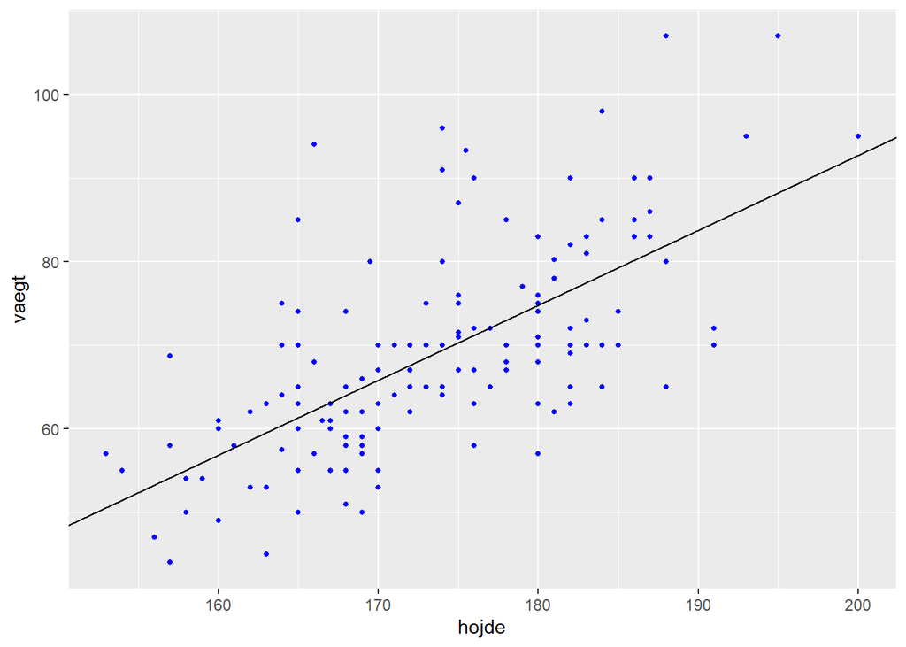

```r
alpha <- as.numeric(coef(linreg)[1]) # Intercept
beta <- as.numeric(coef(linreg)[2]) # Slope

ggplot(data = data_horse, aes(x = hojde, y = vaegt)) +
  geom_point(color = "blue", size = 1) + # Scatter
  geom_abline(slope = beta, intercept = alpha) # line
```

## Opgave 2

Filtrer på kvinder

```r
df_k_horse <- subset(data_horse, kon == "Kvinde")
```

## Opgave 3

Lav en passende figur der viser data.

```r
linreg_k <- lm(vaegt ~ hojde, data = df_k_horse) # Fit
summary(linreg_k)
```

```
##
## Call:
## lm(formula = vaegt ~ hojde, data = df_k_horse)
##
## Residuals:
##     Min      1Q  Median      3Q     Max
## -16.890  -5.688  -1.950   3.342  31.891
##
## Coefficients:
##             Estimate Std. Error t value Pr(>|t|)
## (Intercept) -77.5856    22.9403  -3.382  0.00102 **
## hojde         0.8415     0.1359   6.191  1.3e-08 ***
## ---
## Signif. codes:  0 '***' 0.001 '**' 0.01 '*' 0.05 '.' 0.1 ' ' 1
##
## Residual standard error: 8.999 on 101 degrees of freedom
##   (2 observations deleted due to missingness)
## Multiple R-squared:  0.2751, Adjusted R-squared:  0.2679
## F-statistic: 38.33 on 1 and 101 DF,  p-value: 1.295e-08
```

```r
confint(linreg_k)
```

```
##                    2.5 %     97.5 %
## (Intercept) -123.0929326 -32.078263
## hojde          0.5718928   1.111169
```

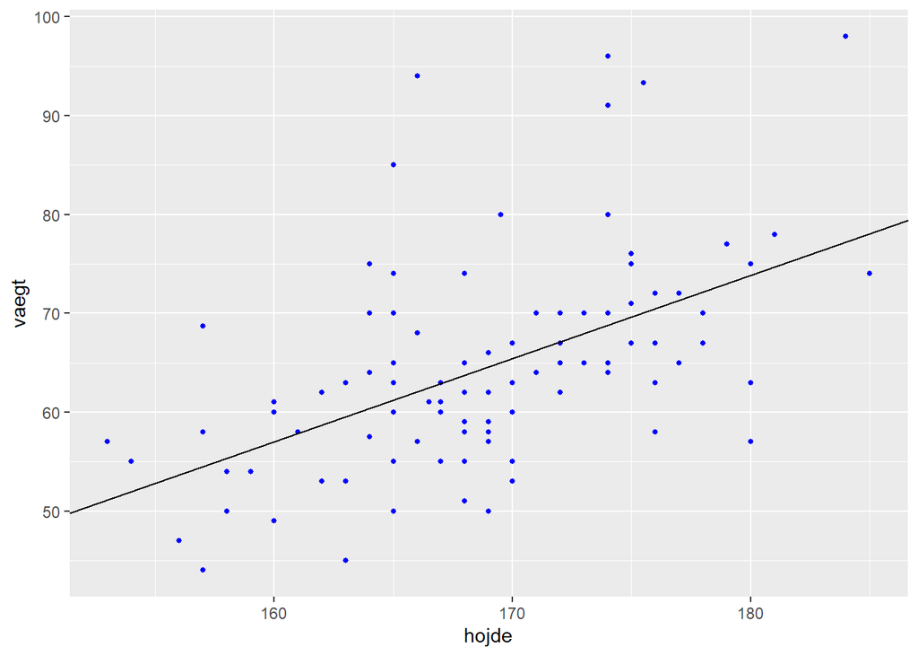

```r
alpha <- as.numeric(coef(linreg_k)[1]) # Intercept
beta <- as.numeric(coef(linreg_k)[2]) # Slope

ggplot(data = df_k_horse, aes(x = hojde, y = vaegt)) +
  geom_point(color = "blue", size = 1) + # Scatter
  geom_abline(slope = beta, intercept = alpha) # line
```

## Opgave 4

Betragt en kvinde p˚a 165 cm, og angiv et estimat for hendes forventede vægt.

Modellen er fittet, vi laver en predektion på vægten

```r
x_kvinder <- data.frame(hojde = 165) # Create data
predict(linreg_k, x_kvinder)
```

```
##        1
## 61.26704
```

## Opgave 5

Angiv estimatet for hældningen og den tilhørende standard error. Bestem ogs˚a 95% konfidensintervallet for hældningen

```r
summary(linreg_k)
```

```
##
## Call:
## lm(formula = vaegt ~ hojde, data = df_k_horse)
##
## Residuals:
##     Min      1Q  Median      3Q     Max
## -16.890  -5.688  -1.950   3.342  31.891
##
## Coefficients:
##             Estimate Std. Error t value Pr(>|t|)
## (Intercept) -77.5856    22.9403  -3.382  0.00102 **
## hojde         0.8415     0.1359   6.191  1.3e-08 ***
## ---
## Signif. codes:  0 '***' 0.001 '**' 0.01 '*' 0.05 '.' 0.1 ' ' 1
##
## Residual standard error: 8.999 on 101 degrees of freedom
##   (2 observations deleted due to missingness)
## Multiple R-squared:  0.2751, Adjusted R-squared:  0.2679
## F-statistic: 38.33 on 1 and 101 DF,  p-value: 1.295e-08
```

```r
confint(linreg_k)
```

```
##                    2.5 %     97.5 %
## (Intercept) -123.0929326 -32.078263
## hojde          0.5718928   1.111169
```

Vi estimere en hældning på 0.8415 og vi antager at den sande ukendte hældning ligger inden for intervallet (0.57, 1.1)

## Opgave 6

Tyder data p˚a at der er en sammenhæng mellem højde og vægt for kvinder?

Hvis der ikke er en sammenhæng mellem højde og vægt har vi at
$$H_0 : \beta = 0$$

Vi ser at 0 ikke ligger inden for vores 95% procent konfidens interval. Da kan en sammenhæng mellem højde og vægt konkluderes.

## Opgave 7

Angiv residualspredningen, dvs. estimatet for spredningen omkrng regressionslinien

Residual standard error: 8.999 on 101 degrees of freedom

## Opgave 8

$$1 \cdot \hat{\beta} = \hat{\beta} =
0.8415$$

Konfidens intervallet må være det samme som for hældningen.

## Opgave 9

Bestem ogs˚a et 95% konfidensinterval for den forventede vægtforskel.

Hmm.. Det er jeg ikke sikker på

```r
x_kvinder <- data.frame(hojde = c(160, 170))

predict(linreg, x_kvinder, interval = "confidence", level = 0.95)
```

```
##        fit      lwr      upr
## 1 56.87393 54.24279 59.50506
## 2 65.85106 64.27134 67.43077
```

```r
jens <- predict(linreg, x_kvinder, interval = "confidence", level = 0.95)

jens[2, 1] - jens[1, 1] # Expected diff
```

```
## [1] 8.977129
```

```r
jens[2, 2] - jens[1, 2] # Lower
```

```
## [1] 10.02854
```

```r
jens[2, 3] - jens[1, 3] # Upper
```

```
## [1] 7.925716
```

## Opgave 10

Fit den tilsvarende model for mændene, og angiv estimat, standard error og konfidensinterval for hældningen i modellen.

```r
df_m_horse <- subset(data_horse, kon == "Mand")


linreg_m <- lm(vaegt ~ hojde, data = df_m_horse) # Fit
summary(linreg_m)
```

```
##
## Call:
## lm(formula = vaegt ~ hojde, data = df_m_horse)
##
## Residuals:
##      Min       1Q   Median       3Q      Max
## -16.9749  -7.8093   0.1907   4.8786  25.0251
##
## Coefficients:
##             Estimate Std. Error t value Pr(>|t|)
## (Intercept) -62.9175    47.3486  -1.329   0.1903
## hojde         0.7707     0.2590   2.976   0.0046 **
## ---
## Signif. codes:  0 '***' 0.001 '**' 0.01 '*' 0.05 '.' 0.1 ' ' 1
##
## Residual standard error: 10.02 on 47 degrees of freedom
##   (2 observations deleted due to missingness)
## Multiple R-squared:  0.1586, Adjusted R-squared:  0.1407
## F-statistic: 8.857 on 1 and 47 DF,  p-value: 0.004601
```

```r
confint(linreg_m)
```

```
##                   2.5 %    97.5 %
## (Intercept) -158.170714 32.335657
## hojde          0.249736  1.291673
```

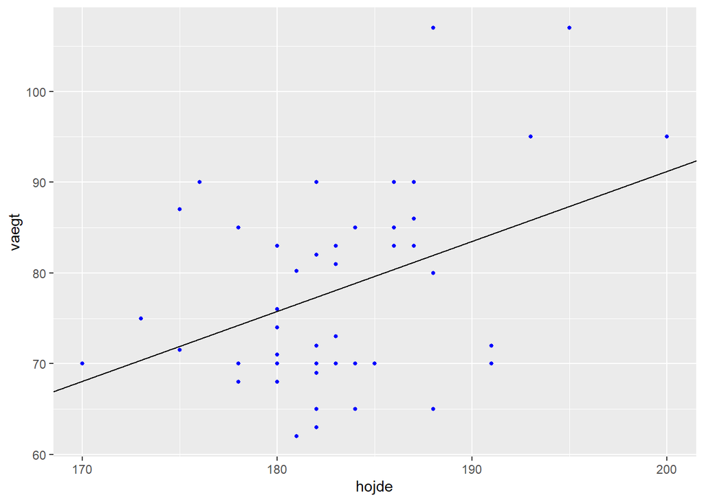

```r
alpha <- as.numeric(coef(linreg_m)[1]) # Intercept
beta <- as.numeric(coef(linreg_m)[2]) # Slope

ggplot(data = df_m_horse, aes(x = hojde, y = vaegt)) +
  geom_point(color = "blue", size = 1) + # Scatter
  geom_abline(slope = beta, intercept = alpha) # line
```

## Opgave 11

Vi husker at
$$SE =
\frac{\sigma}{\sqrt{n}}$$

```r
nrow(df_m_horse)
```

```
## [1] 51
```

```r
nrow(df_k_horse)
```

```
## [1] 105
```

Der er over dobbelt så mange observationer for kvinder ift. mænd. Da bliver nævneren større for kvinder og SE mindre.

## Opgave 12

```r
coefficients(summary(linreg_m))[2,1]
```

```
## [1] 0.7707045
```

```r
coefficients(summary(linreg_k))[2,1]
```

```
## [1] 0.8415311
```

```r
confint(linreg_m)
```

```
##                   2.5 %    97.5 %
## (Intercept) -158.170714 32.335657
## hojde          0.249736  1.291673
```

```r
confint(linreg_k)
```

```
##                    2.5 %     97.5 %
## (Intercept) -123.0929326 -32.078263
## hojde          0.5718928   1.111169
```

Nej, selvom der er forskel på den estimeret hældning, så er hældningen for mændene også forbundet med en del usikkerhed. Ser vi på kofindens intervallet er der et meget stort overlap hvilket vil sige at den sande værdi godt kan være ens for de to grupper.

# Bog 5.8

```r
library("isdals")
data("hazard")
head(hazard , n=3)
```

```
##     type sorption
## 1 estere     0.29
## 2 estere     0.06
## 3 estere     0.44
```

## Opgave 1

Anova kontinuert og kategorisk

## Opgave 2 + 3

```r
anova <- lm(sorption ~ type - 1, data = hazard)
summary(anova)
```

```
##
## Call:
## lm(formula = sorption ~ type - 1, data = hazard)
##
## Residuals:
##      Min       1Q   Median       3Q      Max
## -0.52625 -0.16000  0.00889  0.18500  0.39375
##
## Coefficients:
##              Estimate Std. Error t value Pr(>|t|)
## typearomatic  0.94222    0.07835  12.025 8.61e-13 ***
## typechlor     0.95625    0.08311  11.506 2.50e-12 ***
## typeestere    0.33000    0.06069   5.437 7.53e-06 ***
## ---
## Signif. codes:  0 '***' 0.001 '**' 0.01 '*' 0.05 '.' 0.1 ' ' 1
##
## Residual standard error: 0.2351 on 29 degrees of freedom
## Multiple R-squared:  0.9136, Adjusted R-squared:  0.9046
## F-statistic: 102.2 on 3 and 29 DF,  p-value: 1.61e-15
```

## Opgave 4

```r
sum_hazard <- summarize(group_by(hazard, type), n = n(),
          mean_sorption = mean(sorption), sd_sorption = sd(sorption))
sum_hazard
```

```
## # A tibble: 3 × 4
##   type         n mean_sorption sd_sorption
##   <fct>    <int>         <dbl>       <dbl>
## 1 aromatic     9         0.942       0.168
## 2 chlor        8         0.956       0.332
## 3 estere      15         0.33        0.208
```

```r
# aromatic - chlor
diff_mean_a_c <-sum_hazard$mean_sorption[1] - sum_hazard$mean_sorption[2]
# aromatic - estere
diff_mean_a_e <-sum_hazard$mean_sorption[1] - sum_hazard$mean_sorption[3]
# estere - chlor
diff_mean_c_e <- sum_hazard$mean_sorption[2] - sum_hazard$mean_sorption[3]

diff_mean_a_c
```

```
## [1] -0.01402778
```

```r
diff_mean_a_e
```

```
## [1] 0.6122222
```

```r
diff_mean_c_e
```

```
## [1] 0.62625
```

```r
### Compute pairwise standard error
#aromatic and chlor
0.2351 * sqrt((1/9) + (1/8))
```

```
## [1] 0.1142381
```

```r
# aromatic  and estere
0.2351 * sqrt((1/9) + (1/15))
```

```
## [1] 0.09912686
```

```r
# estere and chlor
0.2351 * sqrt((1/15) + (1/8))
```

```
## [1] 0.1029262
```

## Opgave 5

Compute 95% confidence intervals for the pairwise differences between the expected values for the types. What is the conclusion regarding differences between the three solvent types?

```r
diff_mean_a_c + c(-1, 1) * qt(0.975, df = (9+8-2)) * (0.2351 * sqrt((1/9) + (1/8)))
```

```
## [1] -0.2575205  0.2294649
```

```r
diff_mean_a_e + c(-1, 1) * qt(0.975, df = (9+15-2)) * (0.2351 * sqrt((1/9) + (1/15)))
```

```
## [1] 0.4066457 0.8177988
```

```r
diff_mean_c_e + c(-1, 1) * qt(0.975, df = (8+15-2)) * (0.2351 * sqrt((1/15) + (1/8)))
```

```
## [1] 0.4122033 0.8402967
```

# HS. 15

## Opgave 1

1 stikprøve = 1 gruppe 2 stikprøve = 2 grupper

## Opgave 2

```r
dat1 <- read.table('../uge_2/data/punktplot2017.txt', header=TRUE)
df_dat1 <- data.frame(dat1)
df_dat1
```

```
##     figur1 figur2 figur3
## 1       30     45     25
## 2       60    190     35
## 3       31     48     21
## 4       37     49     28
## 5       80    175     60
## 6       60     50     30
## 7       95     95     50
## 8       51     66     25
## 9       54    104     29
## 10      70    120     50
## 11      68     80     30
## 12      40    100     30
## 13      45     90     40
## 14      48     62     26
```

[output cut: 129 more lines]

```r
m1 <- lm(figur2 ~ 1, data=dat1)
summary(m1)
```

```
##
## Call:
## lm(formula = figur2 ~ 1, data = dat1)
##
## Residuals:
##     Min      1Q  Median      3Q     Max
## -62.301 -26.801  -2.301  22.199 101.699
##
## Coefficients:
##             Estimate Std. Error t value Pr(>|t|)
## (Intercept)  102.301      2.904   35.23   <2e-16 ***
## ---
## Signif. codes:  0 '***' 0.001 '**' 0.01 '*' 0.05 '.' 0.1 ' ' 1
##
## Residual standard error: 34.73 on 142 degrees of freedom
```

```r
confint(m1)
```

```
##                2.5 %   97.5 %
## (Intercept) 96.55955 108.0418
```

```r
m1 <- lm(figur3 ~ 1, data=dat1)
summary(m1)
```

```
##
## Call:
## lm(formula = figur3 ~ 1, data = dat1)
##
## Residuals:
##     Min      1Q  Median      3Q     Max
## -24.874 -10.374   0.126   5.126  65.126
##
## Coefficients:
##             Estimate Std. Error t value Pr(>|t|)
## (Intercept)   44.874      1.199   37.44   <2e-16 ***
## ---
## Signif. codes:  0 '***' 0.001 '**' 0.01 '*' 0.05 '.' 0.1 ' ' 1
##
## Residual standard error: 14.33 on 142 degrees of freedom
```

```r
confint(m1)
```

```
##                2.5 %   97.5 %
## (Intercept) 42.50451 47.24375
```

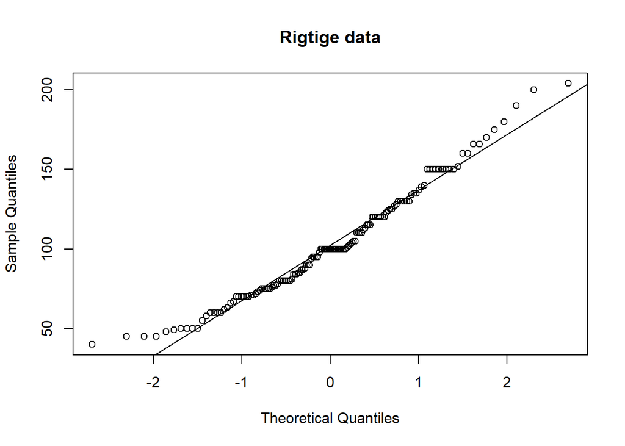

```r
qqnorm(df_dat1$figur2, main = "Rigtige data")
abline(a = mean(df_dat1$figur2), b = sd(df_dat1$figur2))
```

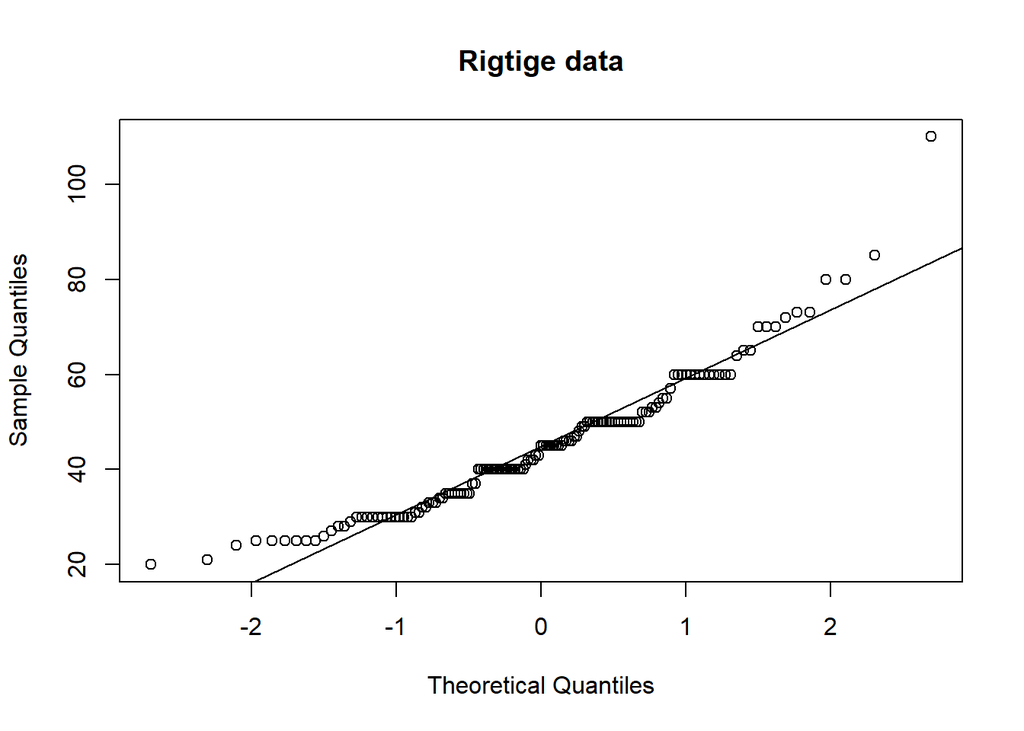

```r
qqnorm(df_dat1$figur3, main = "Rigtige data")
abline(a = mean(df_dat1$figur3), b = sd(df_dat1$figur3))
```